# Prediction of Coronary Artery Disease

Francesco Vo & Marco Uderzo

2023-04-30

Cardiovascular diseases (CVDs) are the number one cause of death globally.

Coronary Heart Disease is a common and very deadly occurrence, and this dataset contains 11 features that can be used to predict it.

People with cardiovascular diseases or who are at high cardiovascular risk need early detection wherein statistical learning models can be of great help.

## Project goal and dataset description

https://www.kaggle.com/datasets/fedesoriano/heart-failure-prediction

The dataset consists of medical data from 5 different hospitals. This data informs us of the presence of coronary heart disease.

Our main goal is to predict the presence of this condition given the other parameters in the dataset.

This dataset has a number of 12 parameters and presents us 918 observations.

The parameters are:

1. **Age**: age of the patient [years]
2. **Sex**: sex of the patient [M: male, F: female]
3. **ChestPainType**: chest pain type [TA: typical angina, ATA: atypical angina, NAP: non-anginal pain, ASY: asymptomatic]. Angina is a type of chest pain caused by reduced blood flow to the heart. Angina is a symptom of coronary heart disease.
4. **RestingBP**: resting blood pressure [mmHg]
5. **Cholesterol**: serum cholesterol [mm/dl]
6. **FastingBS**: fasting blood sugar [1: if FastingBS > 120 mg/dl, 0: otherwise]. This measures the blood sugar level after an overnight fast.
7. **RestingECG**: resting electrocardiogram results [Normal: normal, ST: having ST-T wave abnormality (T wave inversions and/or ST elevation or depression of > 0.05 mV), LVH: showing probable or definite left ventricular hypertrophy by Estes’ criteria]
8. **MaxHR**: maximum heart rate achieved [numeric value between 60 and 202]
9. **ExerciseAngina**: exercise-induced angina [Y: yes, N: no]
10. **Oldpeak**: oldpeak = ST [numeric value between -2.6 and 6.2]. ST depression refers to a finding on an electrocardiogram, wherein the trace in the ST segment is abnormally low below the baseline. Oldpeak measures the depression of the ST slope induced by exercise relative to rest.
11. **ST_Slope**: the slope of the peak exercise ST segment [Up: upsloping, Flat: flat, Down: downsloping]
12. **HeartDisease**: output class [1: heart disease, 0: normal]

## Data visualization and cleaning

In this section we want to visualize our data and clean it. In order to that we have to:

- Visualize the distribution of the target variable
- Visualize the distribution of the predictors
- Deal with missing values
- Deal with outliers
- Find correlations between the parameters

### Data balance check

```r
prop.table(table(HeartDisease))
```

```
## HeartDisease
##         0         1
## 0.4466231 0.5533769
```

The target variable is quite balanced.

### Continuous variables

Now we plot the continuous variables with respect to the target variable.

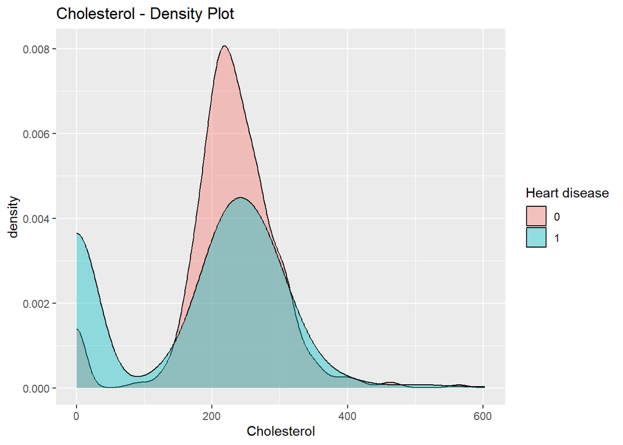

```r
chol.plot
```

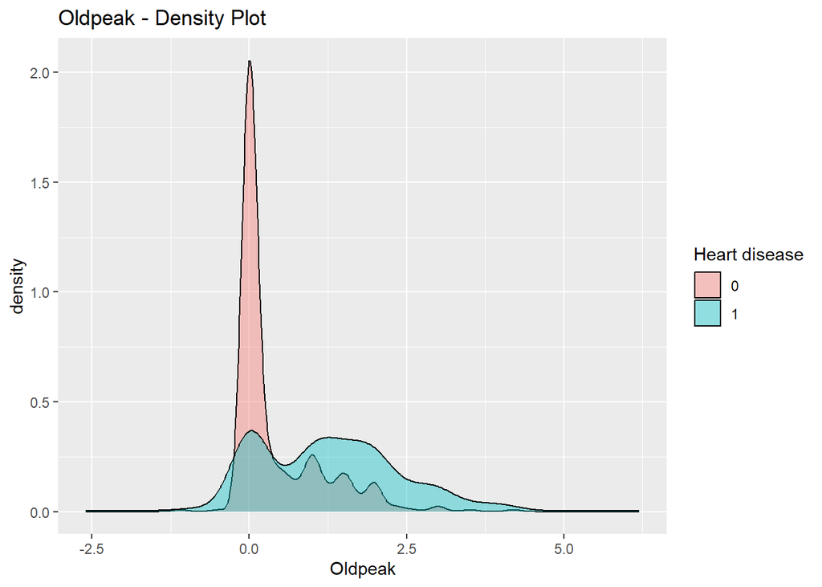

```r
oldpeak.plot
```

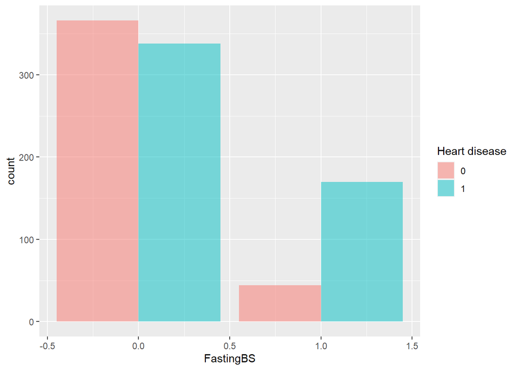

```r
fastingBS.plot
```

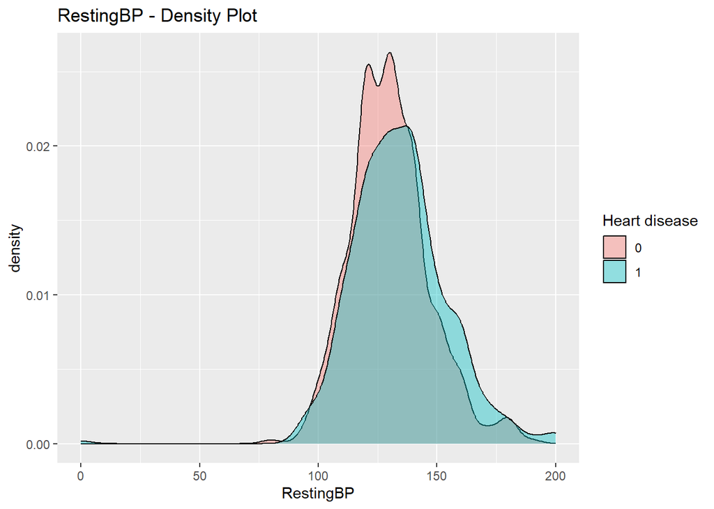

```r
restingBP.plot
```

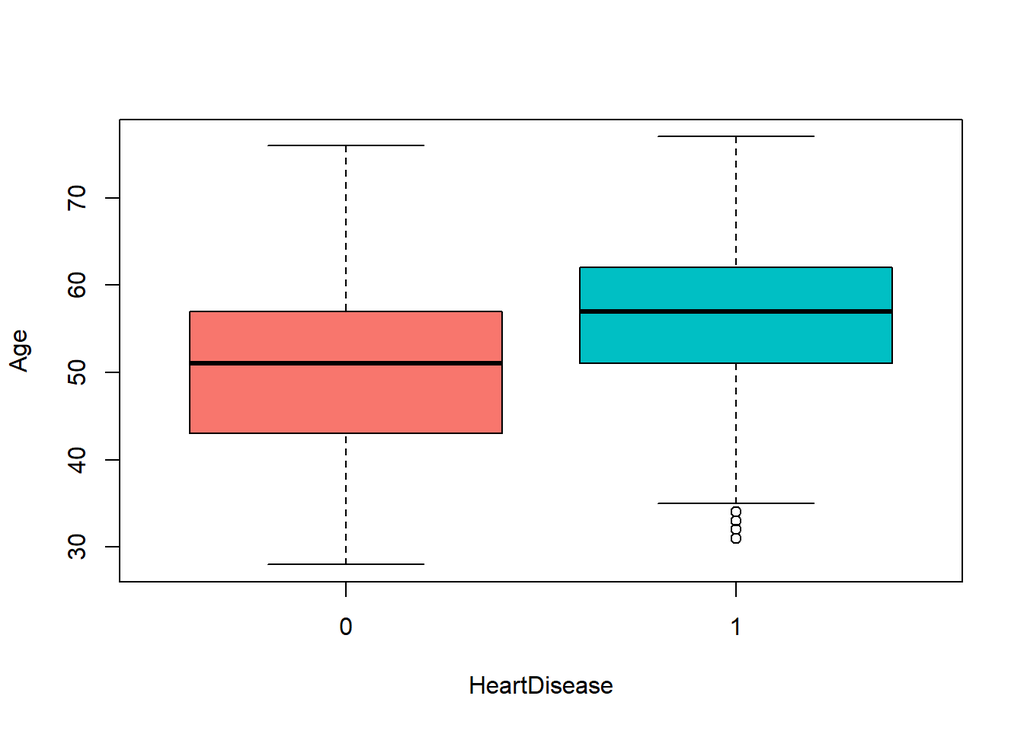

```r
age.box <- boxplot(Age ~ HeartDisease, col=colours)
```

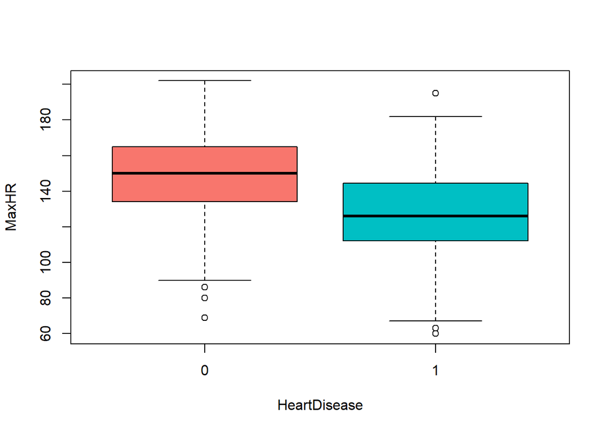

```r
maxHR.box <- boxplot(MaxHR ~ HeartDisease, col=colours)
```

### Categorical variables

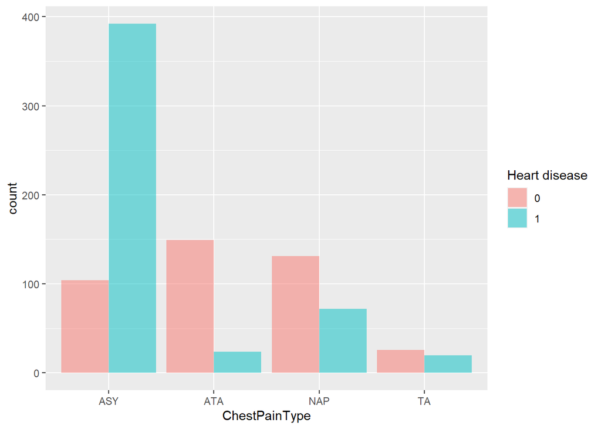

```r
cpt.plot
```

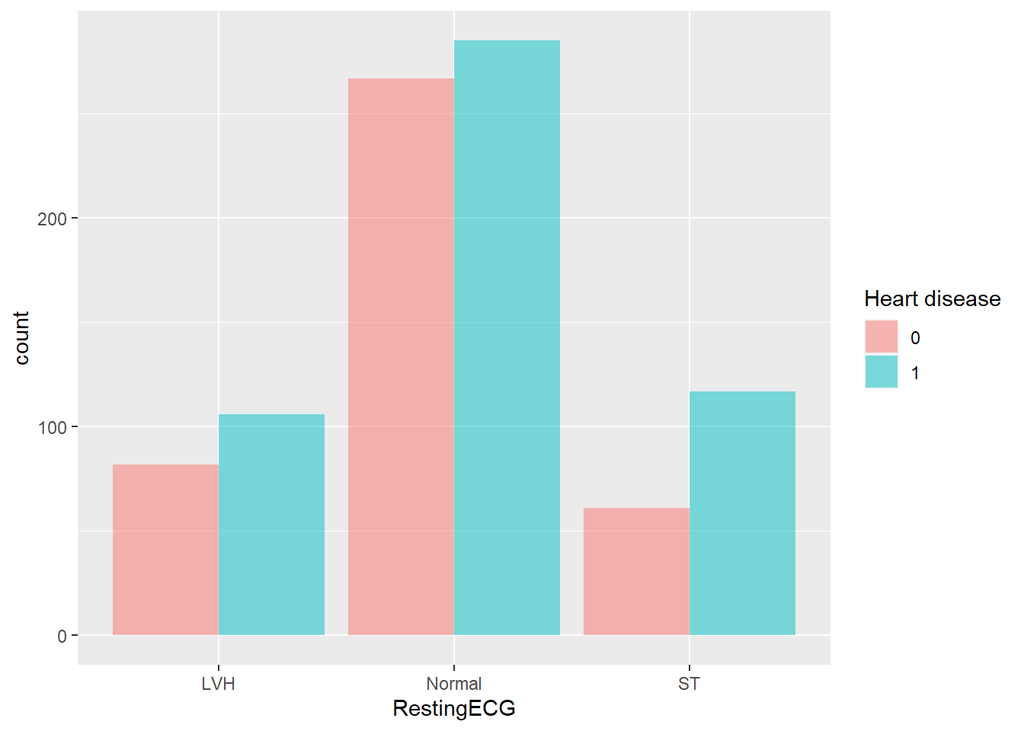

```r
restingECG.plot
```

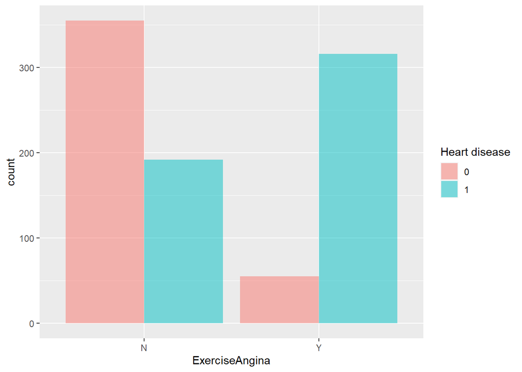

```r
exAn.plot
```

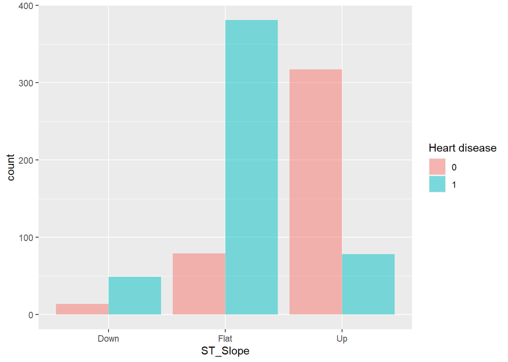

```r
st.plot
```

### Missing values

We have seen from the plots that there are 172 variables in Cholesterol that have value equal to 0. Also we have noted that patients that have Cholesterol equal to 0 are very likely to have the heart disease.

One possibility is that the measurements were taken after the patient was dead, but if we inspect we see that the rows with missing data have RestingBP and MaxHR greater than 0 and RestingECG readings include “Normal” so it safe to assume that these patients are alive and the Cholesterol value was incorrectly recorded.

Another guess is that the “serum cholesterol” measured by this variable combines the HDL and LDL values. High HDL and LDL would cancel each other out, making this variable less useful.

```r
head(data[Cholesterol == 0, c("RestingBP", "MaxHR", "RestingECG")])
```

```
##     RestingBP MaxHR RestingECG
## 294       115    93     Normal
## 295        95   127     Normal
## 296       105   110     Normal
## 297       145   139     Normal
## 298       110   131         ST
## 299       110    92     Normal
```

### Correlations

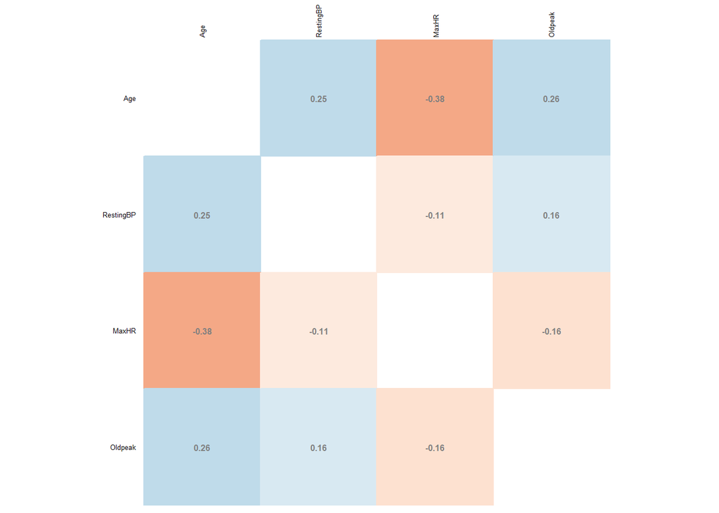

```r
cont.idx <- c(1,4,8,10)

cor.data <- cor(data[,cont.idx])
corrplot(cor.data,
         method="color",
         diag=F,
         tl.cex=0.4,
         number.cex=0.5,
         tl.col="black",
         addCoef.col="grey50",
         cl.pos="n")
```

### Graph

We visualize the igraph to see the relationships between the continuous variables.

```r
S <- var(data[,cont.idx])
R <- -cov2cor(solve(S))
G <- abs(R)>0.1
diag(G) <- 0
```

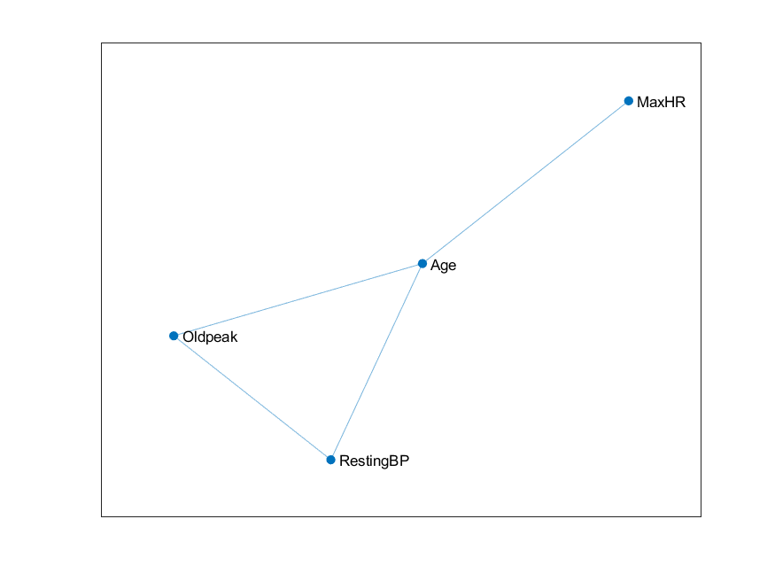

### Data Preparation

We divide our data in the training set and the test set.

```r
set.seed(123)
split <- initial_split(data[,-c(5)], prop=0.75)

train <- training(split)
test <- testing(split)
```

## Evaluation

We chose to try different classification models, like Logistic Regression, Naive Bayes, LDA and QDA. For the former, we also used Lasso Regression and Ridge Regression. The goal is to predict whether or not heart disease is present in the patient.

### LDA

Linear Discriminant Analysis (LDA) is a classification algorithm, where a discriminant rule tries to divide the data points into K disjoint regions, where K is the number of classes (in this case K = 2).

To do that we assume that our data follows a normal distribution and the classes have the same variance, and then we define a discriminant function, which tells us how likely is the observation to follow into a particular class.

$$\delta_{k}(x) = log(f_{k}) +
log(\pi_{k})$$
The decision boundary separating the classes is the set of x where two discriminant functions have the same value. Therefore, any data that falls on the decision boundary is equally likely from all the classes.

```r
lda.fit <- lda(HeartDisease~., data=train)
lda.fit
```

```
## Call:
## lda(HeartDisease ~ ., data = train)
##
## Prior probabilities of groups:
##         0         1
## 0.4462209 0.5537791
##
## Group means:
##        Age      SexM ChestPainTypeATA ChestPainTypeNAP ChestPainTypeTA
## 0 50.27687 0.6351792       0.38436482        0.3355049      0.05537459
## 1 55.67979 0.8923885       0.03937008        0.1338583      0.04724409
##   RestingBP FastingBS RestingECGNormal RestingECGST    MaxHR ExerciseAnginaY
## 0  130.0847 0.1205212        0.6742671    0.1368078 149.1075       0.1400651
## 1  134.7559 0.3228346        0.5800525    0.2099738 128.5774       0.6089239
##     Oldpeak ST_SlopeFlat ST_SlopeUp
## 0 0.4201954    0.1986971  0.7654723
## 1 1.3102362    0.7664042  0.1469816
##
## Coefficients of linear discriminants:
##                           LD1
## Age               0.009930689
## SexM              0.744352146
## ChestPainTypeATA -1.182848798
## ChestPainTypeNAP -1.075687933
## ChestPainTypeTA  -0.660875986
## RestingBP        -0.001194828
## FastingBS         0.561717985
## RestingECGNormal  0.001854152
## RestingECGST      0.036571241
## MaxHR            -0.005711702
## ExerciseAnginaY   0.319998463
## Oldpeak           0.217810362
## ST_SlopeFlat      0.719835027
## ST_SlopeUp       -0.760627954
```

```r
lda.pred <- predict(lda.fit, test, type="response")
lda.res <- lda.pred$posterior

# if we want to minimize the false positives the best result is when t = 0.6
lda.pred.best <- as.factor(ifelse(lda.res[,2] > 0.6, 1, 0))

lda.conf.mat <- table(test$HeartDisease, lda.pred.best)
lda.conf.mat
```

```
##    lda.pred.best
##       0   1
##   0  89  14
##   1  17 110
```

```r
# accuracy, precision, recall, f1 score
lda.metrics <- calculate.metrics(lda.conf.mat)
lda.metrics
```

```
## [[1]]
## [1] 0.8652174
##
## [[2]]
## [1] 0.8870968
##
## [[3]]
## [1] 0.8661417
##
## [[4]]
## [1] 0.876494
##
## [[5]]
## [1] 0.1129032
```

The Receiver Operating Characteristics traces out two types of error as we vary the threshold for the posterior probability:

- The true positive rate or sensitivity: the fraction of patients having the heart condition that are correctly identified
- The false positive rate: the fraction of patients without the conditions that we classify incorrectly with having the disease

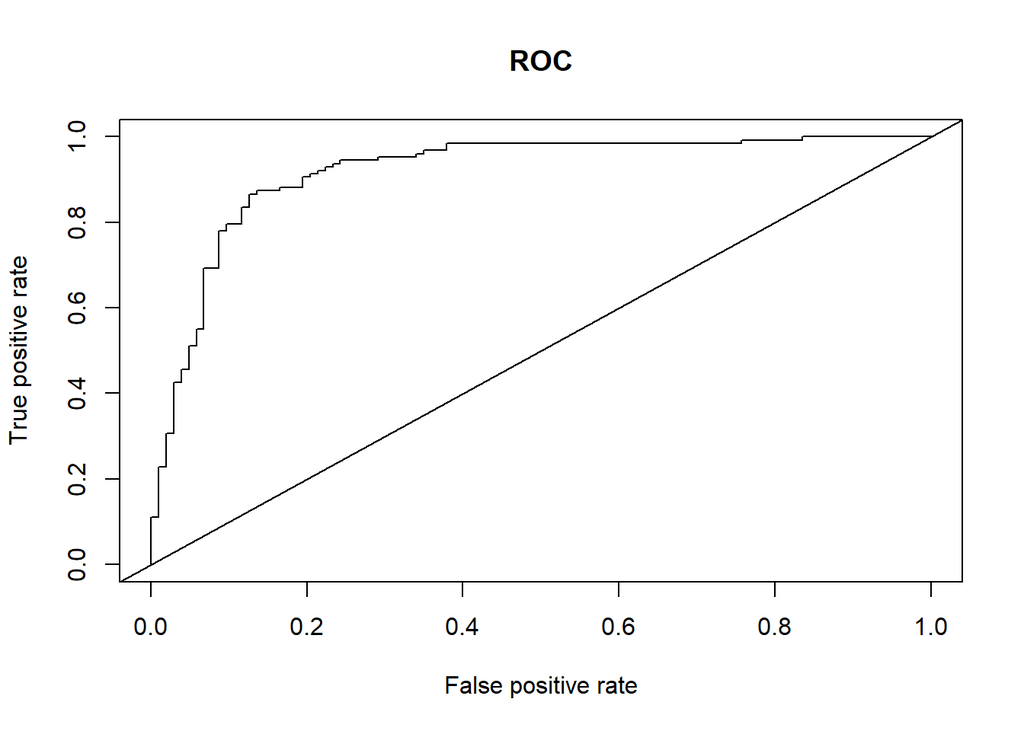

```r
# ROC
lda.auc <- model.plot.roc(lda.res[,2], test$HeartDisease)
```

```r
lda.auc
```

```
## [[1]]
## [1] 0.9184313
```

```r
# ldahist(lda.pred$x[,1], g=lda.pred$class, col=2)
```

### QDA

Quadratic Discriminant Analysis (QDA) doesn’t assume the equal variance of the classes. For this reason the decision boundary is not linear but quadratic.

```r
qda.fit <- qda(HeartDisease~., data=train)

qda.pred <- predict(qda.fit, test)
qda.pred.best <- as.factor(ifelse(lda.res[,2] > 0.5, 1, 0))

qda.conf.mat <- table(qda.pred.best, test$HeartDisease)
qda.conf.mat
```

```
##
## qda.pred.best   0   1
##             0  86  16
##             1  17 111
```

```r
qda.metrics <- calculate.metrics(qda.conf.mat)
qda.metrics
```

```
## [[1]]
## [1] 0.8565217
##
## [[2]]
## [1] 0.8740157
##
## [[3]]
## [1] 0.8671875
##
## [[4]]
## [1] 0.8705882
##
## [[5]]
## [1] 0.1259843
```

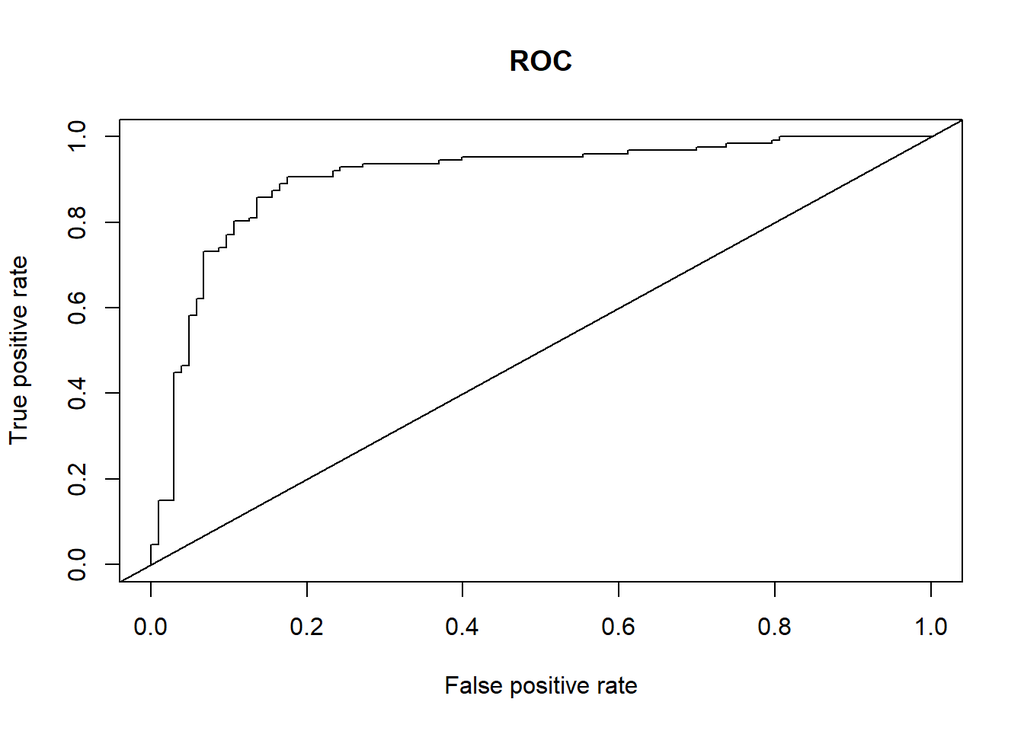

```r
qda.auc <- model.plot.roc(qda.pred$posterior[,2], test$HeartDisease)
```

```r
qda.auc
```

```
## [[1]]
## [1] 0.9049767
```

### Generalized Linear Model and Simple Logistic Regression

Logistic Regression is the easiest and most common model to perform binary classification. The family set is binomial, as the dependent variable is binary.

```r
glm.model <- glm(data=train, HeartDisease~., family="binomial")
glm_summary <- summary(glm.model)
glm_summary
```

```
##
## Call:
## glm(formula = HeartDisease ~ ., family = "binomial", data = train)
##
## Deviance Residuals:
##     Min       1Q   Median       3Q      Max
## -2.6319  -0.3844   0.1899   0.4603   2.6882
##
## Coefficients:
##                   Estimate Std. Error z value Pr(>|z|)
## (Intercept)      -0.729042   1.655480  -0.440 0.659661
## Age               0.016965   0.015332   1.106 0.268515
## SexM              1.637864   0.309104   5.299 1.17e-07 ***
## ChestPainTypeATA -2.065007   0.384651  -5.369 7.94e-08 ***
## ChestPainTypeNAP -1.793251   0.300011  -5.977 2.27e-09 ***
## ChestPainTypeTA  -1.248445   0.481761  -2.591 0.009558 **
## RestingBP        -0.001390   0.006328  -0.220 0.826185
## FastingBS         1.192568   0.304350   3.918 8.91e-05 ***
## RestingECGNormal  0.024583   0.306841   0.080 0.936144
## RestingECGST     -0.008478   0.407053  -0.021 0.983383
## MaxHR            -0.010893   0.005753  -1.894 0.058272 .
## ExerciseAnginaY   0.527693   0.281275   1.876 0.060645 .
## Oldpeak           0.473929   0.135637   3.494 0.000476 ***
## ST_SlopeFlat      1.574485   0.503922   3.124 0.001781 **
## ST_SlopeUp       -0.753010   0.518186  -1.453 0.146178
## ---
## Signif. codes:  0 '***' 0.001 '**' 0.01 '*' 0.05 '.' 0.1 ' ' 1
##
## (Dispersion parameter for binomial family taken to be 1)
##
##     Null deviance: 945.80  on 687  degrees of freedom
## Residual deviance: 449.73  on 673  degrees of freedom
## AIC: 479.73
##
## Number of Fisher Scoring iterations: 5
```

We calculate the odds of success given the R-squared value, so that we evaluate the model error. R-squared is the percentage of the dependent variable variation that a linear model explains. 0% represents a model that does not explain any of the variation in the response variable around its mean. The mean of the dependent variable predicts the dependent variable as well as the regression model.

```r
r2 <- 1 - (glm_summary$deviance/glm_summary$null.deviance)
r2
```

```
## [1] 0.5244986
```

We run the model on the test data, with an initial threshold value of 0.6, to be tuned later through Variable Selection

```r
prediction.glm.model <- predict(glm.model, newdata=test, type="response")
prediction.glm.model.binary <- ifelse(prediction.glm.model > 0.6, 1, 0)

conf_matrix <- table(test$HeartDisease, prediction.glm.model.binary)
glm.model.metrics <- calculate.metrics(conf_matrix)
glm.model.metrics
```

```
## [[1]]
## [1] 0.8652174
##
## [[2]]
## [1] 0.9067797
##
## [[3]]
## [1] 0.8425197
##
## [[4]]
## [1] 0.8734694
##
## [[5]]
## [1] 0.09322034
```

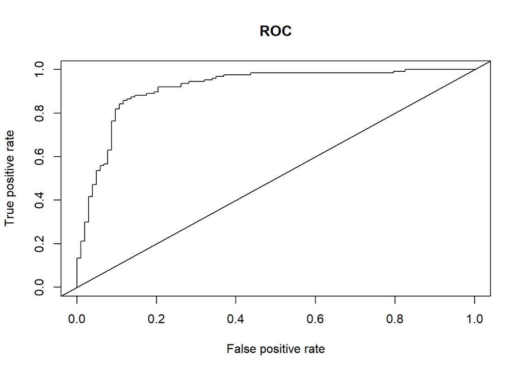

```r
glm.model.auc <- model.plot.roc(prediction.glm.model, test$HeartDisease)
```

```r
glm.model.auc
```

```
## [[1]]
## [1] 0.9163673
```

### Backward Variable Selection using p-value

All statistical tests have a null hypothesis. For most tests, the null hypothesis is that there is no relationship between your variables of interest or that there is no difference among groups. The p value, or probability value, tells how likely it is that the data could have occurred under the null hypothesis. It does this by calculating the likelihood of the test statistic, which is the number calculated by a statistical test using the data.

The p value tells how often one would expect to see a test statistic as extreme or more extreme than the one calculated by the statistical test if the null hypothesis of that test was true. The p value gets smaller as the test statistic calculated from the data gets further away from the range of test statistics predicted by the null hypothesis.

```r
glm.model.1 <- update(glm.model, ~. - Age)
glm.model.2 <- update(glm.model.1, ~. - RestingECG)
glm.model.3 <- update(glm.model.2, ~. - MaxHR)
glm.model.4 <- update(glm.model.3, ~. - RestingBP)

summary(glm.model.4)
```

```
##
## Call:
## glm(formula = HeartDisease ~ Sex + ChestPainType + FastingBS +
##     ExerciseAngina + Oldpeak + ST_Slope, family = "binomial",
##     data = train)
##
## Deviance Residuals:
##     Min       1Q   Median       3Q      Max
## -2.6079  -0.3822   0.1823   0.4549   2.9278
##
## Coefficients:
##                  Estimate Std. Error z value Pr(>|z|)
## (Intercept)       -1.5474     0.5988  -2.584 0.009766 **
## SexM               1.6924     0.3074   5.505 3.69e-08 ***
## ChestPainTypeATA  -2.1879     0.3820  -5.727 1.02e-08 ***
## ChestPainTypeNAP  -1.8944     0.2929  -6.467 1.00e-10 ***
## ChestPainTypeTA   -1.3656     0.4776  -2.859 0.004248 **
## FastingBS          1.2972     0.2987   4.342 1.41e-05 ***
## ExerciseAnginaY    0.6864     0.2685   2.557 0.010560 *
## Oldpeak            0.4639     0.1305   3.556 0.000377 ***
## ST_SlopeFlat       1.6074     0.4910   3.274 0.001062 **
## ST_SlopeUp        -0.8304     0.5041  -1.647 0.099497 .
## ---
## Signif. codes:  0 '***' 0.001 '**' 0.01 '*' 0.05 '.' 0.1 ' ' 1
##
## (Dispersion parameter for binomial family taken to be 1)
##
##     Null deviance: 945.80  on 687  degrees of freedom
## Residual deviance: 456.95  on 678  degrees of freedom
## AIC: 476.95
##
## Number of Fisher Scoring iterations: 5
```

Let’s now compute the R-squared and the Variance Inflation Factor (VIF) for each model

R-squared is a measure of how well the model explains the data and of how much variance in the dependent variable is explained by the independent variables in the model. The VIF, on the other hand, is a measure of how much the variance of the estimated regression coefficient for a given independent variable is inflated due to multicollinearity.

A VIF value of 1 indicates no multicollinearity. Values between 1 and 5 indicates moderate correlation between a given predictor variable and other predictor variables in the model, but not severe enough to require attention. A value greater than 5 indicates potentially severe correlation between a given predictor variable and other predictor variables in the model. In this case, the coefficient estimates and p-values in the regression output are likely unreliable.

```r
glm.models = list(glm.model, glm.model.1, glm.model.2, glm.model.3, glm.model.4)

i=0
for (mdl in glm.models){
  r2 <- 1 - (mdl$deviance/mdl$null.deviance)
  vif <- 1/(1-r2)
  cat("GLM Model ", i, " - ", "VIF: ", vif, "\n")
  i=i+1
}
```

```
## GLM Model  0  -  VIF:  2.103043
## GLM Model  1  -  VIF:  2.09731
## GLM Model  2  -  VIF:  2.097167
## GLM Model  3  -  VIF:  2.06998
## GLM Model  4  -  VIF:  2.069784
```

Each model’s VIF indicate some minor, although not severe, correlation between predictor

### Bayesian Information Criterion (BIC)

The Bayesian Information Criterion, often abbreviated BIC, is a metric that is used to compare the goodness of fit of different regression models.

```r
glm.models = list(glm.model, glm.model.1, glm.model.2, glm.model.3, glm.model.4)

i=0
for (mdl in glm.models){
  glm.bic <- BIC(mdl)
  cat("GLM Model ", i, " - ","BIC: ", glm.bic, "\n")
  i=i+1
}
```

```
## GLM Model  0  -  BIC:  547.7341
## GLM Model  1  -  BIC:  542.4296
## GLM Model  2  -  BIC:  529.3928
## GLM Model  3  -  BIC:  528.7822
## GLM Model  4  -  BIC:  522.2917
```

Lower BIC means better model. So, the best model is glm.model.4 with a BIC of 522.2917.

### Analysis of Deviance

Deviance is a quality-of-fit statistic for a model that is often used for statistical hypothesis testing.

```r
# Full model

glm.model.full <- glm(data=train, HeartDisease~., family="binomial")

deviance(glm.model.full)
```

```
## [1] 449.7273
```

```r
pi.hat <- predict(glm.model.full, type="response")
DF <- -2*sum(train$HeartDisease*log(pi.hat)+(1-train$HeartDisease)*log(1-pi.hat))


df.F <- glm.model.full$df.residual



glm.model.reduced <- glm.model.4


deviance(glm.model.reduced)
```

```
## [1] 456.9539
```

```r
pi.hat <- predict(glm.model.reduced, type="response")
DR <- -2*sum(train$HeartDisease*log(pi.hat)+(1-train$HeartDisease)*log(1-pi.hat))

df.R <- glm.model.reduced$df.residual


# Deviance difference test

dev.test <- DR-DF

df <- df.R- df.F


pvalue <- 1-pchisq(dev.test, df)
pvalue
```

```
## [1] 0.2043263
```

```r
# deviance difference using the anova() function

anova(glm.model.reduced, glm.model.full, test="Chisq")
```

```
## Analysis of Deviance Table
##
## Model 1: HeartDisease ~ Sex + ChestPainType + FastingBS + ExerciseAngina +
##     Oldpeak + ST_Slope
## Model 2: HeartDisease ~ Age + Sex + ChestPainType + RestingBP + FastingBS +
##     RestingECG + MaxHR + ExerciseAngina + Oldpeak + ST_Slope
##   Resid. Df Resid. Dev Df Deviance Pr(>Chi)
## 1       678     456.95
## 2       673     449.73  5   7.2266   0.2043
```

In this case, the high p-value of 0.2043 tells us that the reduced model is not significantly different from the full model. Therefore, the removed predictors are indeed not useful.

### Threshold Selection

.

```r
thresholds = c(0.3, 0.4, 0.5, 0.6)

for (thr in thresholds) {

  prediction.glm.model.4 <- predict(glm.model.4, newdata=test, type="response")
  prediction.glm.model.4.binary <- ifelse(prediction.glm.model.4 > thr, 1, 0)

  conf_matrix <- table(test$HeartDisease, prediction.glm.model.4.binary)
  conf_matrix
  glm.model.4.metrics <- calculate.metrics(conf_matrix)

  cat("Threshold: ", thr, "\n")
  cat("Accuracy, Precision, Rec, F1-Score", paste(glm.model.4.metrics, collapse = ", "), "\n")



}
```

```
## Threshold:  0.3
## Accuracy, Precision, Rec, F1-Score 0.808695652173913, 0.754601226993865, 0.968503937007874, 0.848275862068965, 0.245398773006135
## Threshold:  0.4
## Accuracy, Precision, Rec, F1-Score 0.878260869565217, 0.866666666666667, 0.921259842519685, 0.893129770992366, 0.133333333333333
## Threshold:  0.5
## Accuracy, Precision, Rec, F1-Score 0.865217391304348, 0.869230769230769, 0.889763779527559, 0.879377431906615, 0.130769230769231
## Threshold:  0.6
## Accuracy, Precision, Rec, F1-Score 0.847826086956522, 0.903508771929825, 0.811023622047244, 0.854771784232365, 0.0964912280701754
```

```r
prediction.glm.model.4 <- predict(glm.model.4, newdata=test, type="response")
prediction.glm.model.4.binary <- ifelse(prediction.glm.model.4 > 0.4, 1, 0)

conf_matrix <- table(test$HeartDisease, prediction.glm.model.4.binary)
conf_matrix
```

```
##    prediction.glm.model.4.binary
##       0   1
##   0  85  18
##   1  10 117
```

```r
glm.model.4.metrics <- calculate.metrics(conf_matrix)

cat("Accuracy, Precision, Rec, F1-Score", paste(glm.model.4.metrics, collapse = ", "), "\n")
```

```
## Accuracy, Precision, Rec, F1-Score 0.878260869565217, 0.866666666666667, 0.921259842519685, 0.893129770992366, 0.133333333333333
```

We need to minimize the amount of patients coming in with CHD symptoms that are wrongly predicted not to have CHD. This is because discharging the patient and them having a heart attack outside of the hospital greatly lowers their probability of survival. Therefore, although all metrics are important to consider and therefore a compromise has to be made, we need to find the one that maximizes Recall, so that it increases the prediction of patients with the disease, while trying not to lose much on the other metrics. The best overall threshold is 0.4.

Let’s also plot the ROC Curve for the final model.

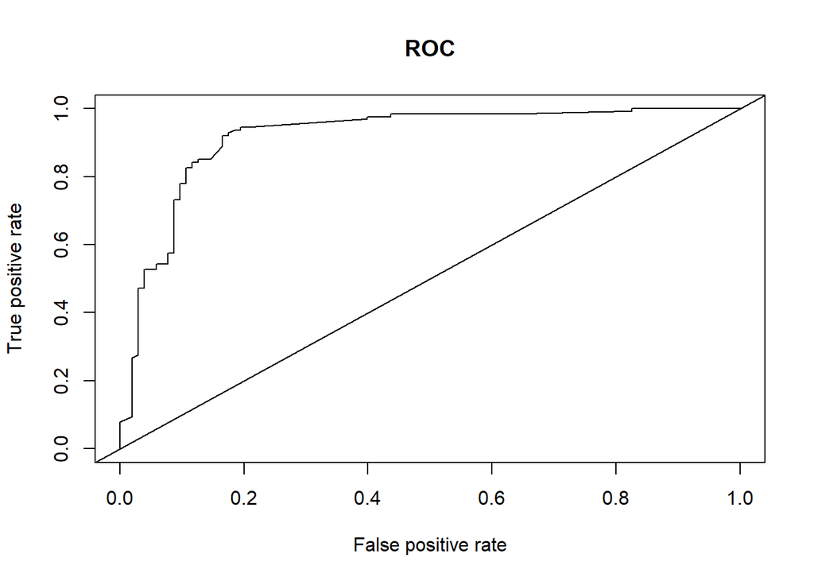

```r
glm.model.4.auc <- model.plot.roc(prediction.glm.model.4, test$HeartDisease)
```

```r
glm.model.4.auc
```

```
## [[1]]
## [1] 0.917514
```

### Lasso Regression

Lasso regression is a regularization technique. It is used over regression methods for a more accurate prediction. This model uses shrinkage (L1 Regularization). The lasso procedure encourages simple, sparse models (i.e. models with fewer parameters).

```r
X <- model.matrix(glm.model)
y <- train$HeartDisease

lasso.model <- cv.glmnet(X, y, family = "binomial", type.measure = "class") #cross-validation handled by glmnet

lasso.coef <- coef(lasso.model, s = "lambda.min")
lasso.vars <- rownames(lasso.coef)[-1][lasso.coef[-1,] != 0]

cat("Selected variables with Lasso Regression:\n\n", paste(lasso.vars, collapse = "\n"))
```

```
## Selected variables with Lasso Regression:
##
##  Age
## SexM
## ChestPainTypeATA
## ChestPainTypeNAP
## FastingBS
## MaxHR
## ExerciseAnginaY
## Oldpeak
## ST_SlopeFlat
## ST_SlopeUp
```

```r
lasso.X_test <- model.matrix(glm.model, data = test)


lasso.y_pred <- predict(lasso.model, newx = lasso.X_test, s = "lambda.min", type = "response")


lasso.y_pred_class <- ifelse(lasso.y_pred > 0.6, 1, 0)  # Convert probabilities to classes


lasso.model
```

```
##
## Call:  cv.glmnet(x = X, y = y, type.measure = "class", family = "binomial")
##
## Measure: Misclassification Error
##
##      Lambda Index Measure      SE Nonzero
## min 0.02754    27  0.1366 0.01510      10
## 1se 0.04385    22  0.1454 0.01227       9
```

```r
lasso.coef
```

```
## 16 x 1 sparse Matrix of class "dgCMatrix"
##                            s1
## (Intercept)       0.557670414
## (Intercept)       .
## Age               0.003422359
## SexM              0.906708935
## ChestPainTypeATA -1.230503452
## ChestPainTypeNAP -0.932959884
## ChestPainTypeTA   .
## RestingBP         .
## FastingBS         0.572709220
## RestingECGNormal  .
## RestingECGST      .
## MaxHR            -0.008990477
## ExerciseAnginaY   0.537545127
## Oldpeak           0.260167015
## ST_SlopeFlat      0.755638448
## ST_SlopeUp       -1.069356700
```

There are some differences between what Lasso decided to remove and what we removed before through Variable Selection. Lasso removed RestingECG, RestingBP and ChestPainTypeTA, while keeping Age and MaxHR. Let’s consider what this might imply, by looking at some of the medical literature.

- Age: Age is an independent risk factor for cardiovascular disease in adults, and the risk increases with age, but these risks are compounded by additional factors. [(Rodgers et al.)](https://www.ncbi.nlm.nih.gov/pmc/articles/PMC6616540/)
- RestingECG: Resting ECG abnormality has been shown to be a strong predictor for mortality and major adverse cardiac events (MACE) in healthy subjects as well as for high-risk populations. [Kaolawanich et al.](https://www.ncbi.nlm.nih.gov/pmc/articles/PMC8714441/#:~:text=Resting%20ECG%20abnormality%20has%20been,populations%20%5B10%2C%2011%5D.)
- MaxHR: Resting heart rate was an independent predictor of coronary artery disease, stroke, sudden death and non-cardiovascular diseases over all of the studies combined. [(Zhang et al.)](https://www.ncbi.nlm.nih.gov/pmc/articles/PMC5056889/)
- RestingBP: Morning HBP is a strong predictor of future CAD and stroke events [(Kario et al.)](https://pubmed.ncbi.nlm.nih.gov/27150682/). With increasing age, there was a gradual shift from DBP to SBP and then to PP (Pulse Pressure) as predictors of CHD risk. In patients <50 years of age, DBP was the strongest predictor. Age 50 to 59 years was a transition period when all 3 BP indexes were comparable predictors, and from 60 years of age on, DBP was negatively related to CHD risk so that PP became superior to SBP. [(Franklin et al.)](https://www.ahajournals.org/doi/10.1161/01.cir.103.9.1245).

From this we can make a couple of observations and comparisons between choices of predictors from medical literature and our statistical analysis:

- First of all, the remaining predictors might be more useful for predicting CHD/CAD, whereas the removed ones contribute less to the prediction. Nonetheless, it is important to consider that we are dealing with statistical models and not with real clinical situations, so, in the clinical sense, all of those predictors are to be considered important to assess the patient’s health.
- RestingECG and RestingBP have been discarded in both of the methods used. Although Resting Blood Pressure is an important predictor, our dataset only contains Systolic Blood Pressure readings, which are not enough to be considered a strong predictors, as seen by the complex difference in the importance of Blood Pressure Types (SBP, DBP, PP) in different Age ranges.
- Max Heart Rate is kept by Lasso Regression, which is a good thing, considering that Heart Rate at rest can be used to assess how efficiently the heart is working. Higher HR at rest means that the heart is working harder without an obvious reason, such as physical exertion, and this can indicate abnormalities in its functions.

```r
lasso.conf.mat <- table(lasso.y_pred_class, test$HeartDisease)
lasso.conf.mat
```

```
##
## lasso.y_pred_class   0   1
##                  0  90  22
##                  1  13 105
```

Let’s calculate the metrics

```r
lasso.metrics <- calculate.metrics(lasso.conf.mat)
lasso.metrics
```

```
## [[1]]
## [1] 0.8478261
##
## [[2]]
## [1] 0.8267717
##
## [[3]]
## [1] 0.8898305
##
## [[4]]
## [1] 0.8571429
##
## [[5]]
## [1] 0.1732283
```

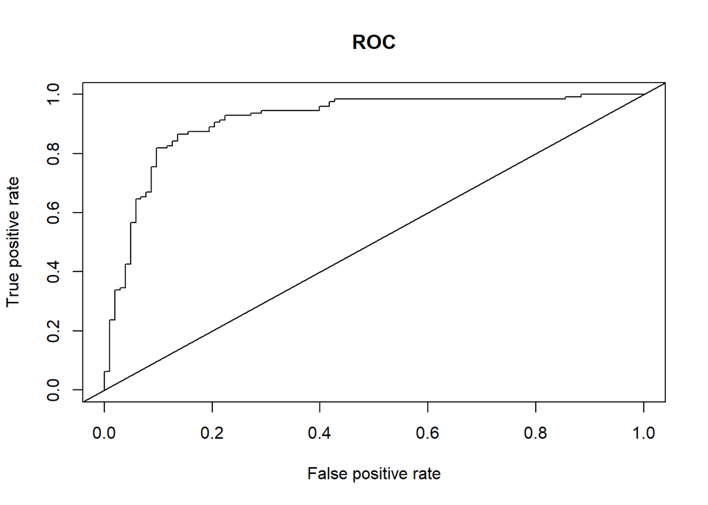

```r
lasso.auc <- model.plot.roc(lasso.y_pred, test$HeartDisease)
```

```r
lasso.auc
```

```
## [[1]]
## [1] 0.9130036
```

### Ridge Regression

Ridge regression is a model tuning method that is used to analyse any data that suffers from multicollinearity. It performs L2 regularization.

Ridge Regression can also be used to check the coefficient estimates, that represent the expected change in the response variable for a one-unit increase in each predictor, holding all other predictors constant.

The negative signs on some of the coefficients indicate that an increase in the corresponding predictor is associated with a decrease in the response variable, while positive signs indicate an increase in the predictor is associated with an increase in the response variable.

```r
X <- model.matrix(glm.model)
y <- train$HeartDisease

ridge.fit <- cv.glmnet(X, y, family = "binomial", alpha = 0, type.measure = "deviance") #cross-validation handled by glmnet

coef(ridge.fit, s = "lambda.min")
```

```
## 16 x 1 sparse Matrix of class "dgCMatrix"
##                             s1
## (Intercept)      -0.2153065726
## (Intercept)       .
## Age               0.0160806001
## SexM              1.1635775828
## ChestPainTypeATA -1.4366194007
## ChestPainTypeNAP -1.2222969859
## ChestPainTypeTA  -0.7173331612
## RestingBP        -0.0004252259
## FastingBS         0.8555164979
## RestingECGNormal -0.0134815370
## RestingECGST      0.0403147074
## MaxHR            -0.0107161566
## ExerciseAnginaY   0.5963713906
## Oldpeak           0.3521643720
## ST_SlopeFlat      1.0208749799
## ST_SlopeUp       -0.9436011441
```

```r
ridge.X_test <- model.matrix(glm.model, data = test)

ridge.y_pred <- predict(ridge.fit, newx = ridge.X_test, s = "lambda.min", type = "response")

ridge.y_pred_class <- ifelse(ridge.y_pred > 0.6, 1, 0)  # Convert probabilities to classes

lambda_min_value <- ridge.fit$lambda.min
lambda_min_value
```

```
## [1] 0.03093615
```

```r
ridge.conf.mat <- table(ridge.y_pred_class, test$HeartDisease)
ridge.conf.mat
```

```
##
## ridge.y_pred_class   0   1
##                  0  92  19
##                  1  11 108
```

```r
ridge.metrics <- calculate.metrics(ridge.conf.mat)
ridge.metrics
```

```
## [[1]]
## [1] 0.8695652
##
## [[2]]
## [1] 0.8503937
##
## [[3]]
## [1] 0.907563
##
## [[4]]
## [1] 0.8780488
##
## [[5]]
## [1] 0.1496063
```

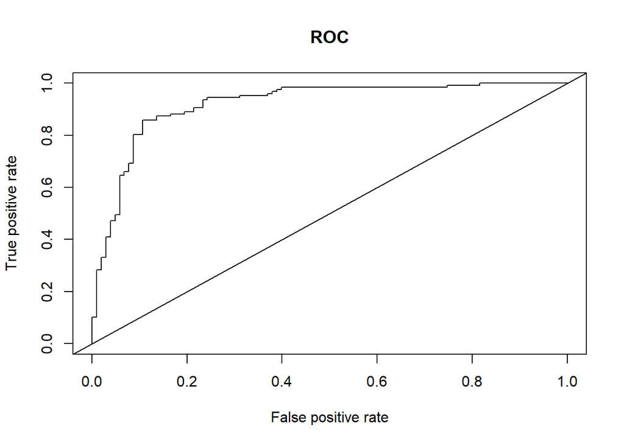

```r
ridge.auc <- model.plot.roc(ridge.y_pred, test$HeartDisease)
```

```r
ridge.auc
```

```
## [[1]]
## [1] 0.9192722
```

### Naive Bayes Classifier

One other model we tried is the Naive Bayes Classifier. It is a classification technique based on Bayes’ Theorem with an independence assumption among predictors. In simple terms, a Naive Bayes classifier assumes that the presence of a particular feature in a class is unrelated to the presence of any other feature.

```r
train$HeartDisease <- as.factor(train$HeartDisease)
test$HeartDisease <- as.factor(test$HeartDisease)


naivebayes.model <- naive_bayes(HeartDisease~., data=test)
naivebayes.prediction <- predict(naivebayes.model, newx = test, type = "prob")
naivebayes.y_pred_class <- ifelse(naivebayes.prediction > 0.6, 1, 0)



naivebayes.conf.mat <- table(naivebayes.y_pred_class[,2], test$HeartDisease)


naivebayes.metrics <- calculate.metrics(naivebayes.conf.mat)
naivebayes.metrics
```

```
## [[1]]
## [1] 0.8652174
##
## [[2]]
## [1] 0.8503937
##
## [[3]]
## [1] 0.9
##
## [[4]]
## [1] 0.8744939
##
## [[5]]
## [1] 0.1496063
```

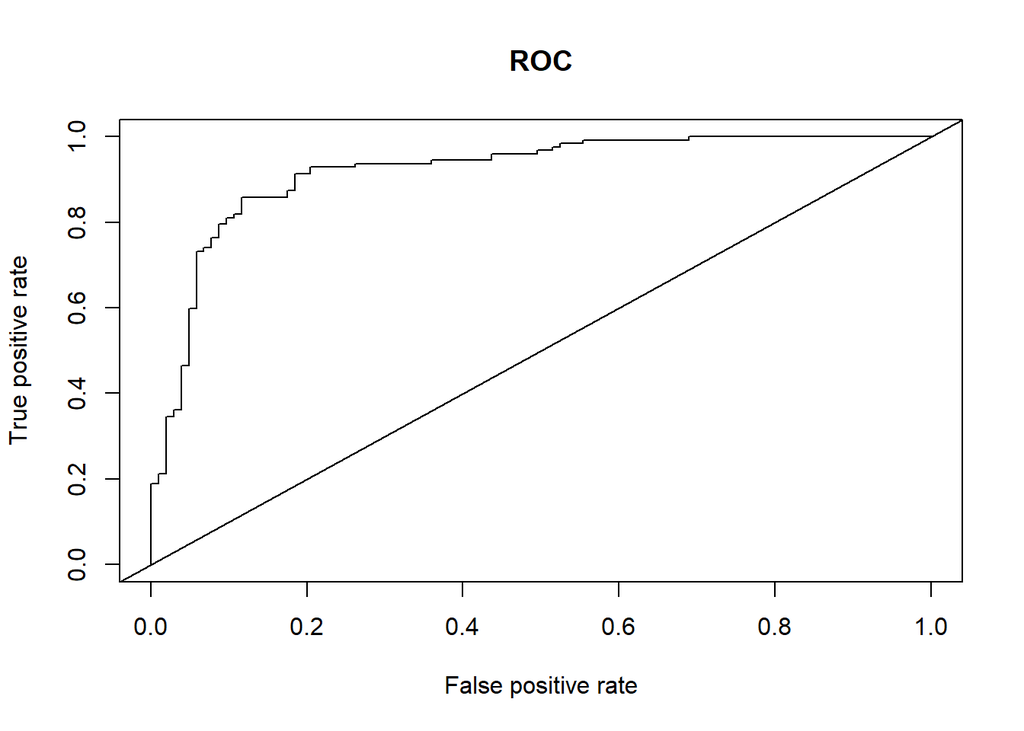

```r
naivebayes.auc <- model.plot.roc(naivebayes.prediction[,2], test$HeartDisease)
```

```r
naivebayes.auc
```

```
## [[1]]
## [1] 0.9195016
```

### Model Comparison

```r
# acc, prec, rec, f1.score

lda.acc <- lda.metrics[1][[1]]
lda.prec <- lda.metrics[2][[1]]
lda.rec <- lda.metrics[3][[1]]
lda.f1 <- lda.metrics[4][[1]]
lda.fn <- lda.metrics[5][[1]]
lda.auc <- lda.auc[[1]]

qda.acc <- qda.metrics[1][[1]]
qda.prec <- qda.metrics[2][[1]]
qda.rec <- qda.metrics[3][[1]]
qda.f1 <- qda.metrics[4][[1]]
qda.fn <- qda.metrics[5][[1]]
qda.auc <- qda.auc[[1]]

glm.4.acc <- glm.model.4.metrics[[1]][[1]]
glm.4.prec <- glm.model.4.metrics[2][[1]]
glm.4.rec <- glm.model.4.metrics[3][[1]]
glm.4.f1 <- glm.model.4.metrics[4][[1]]
glm.4.fn <- glm.model.4.metrics[5][[1]]
glm.4.auc <- glm.model.4.auc[[1]]

lasso.acc <- lasso.metrics[1][[1]]
lasso.prec <- lasso.metrics[2][[1]]
lasso.rec <- lasso.metrics[3][[1]]
lasso.f1 <- lasso.metrics[4][[1]]
lasso.fn <- lasso.metrics[5][[1]]
lasso.auc <- lasso.auc[[1]]

ridge.acc <- ridge.metrics[1][[1]]
ridge.prec <- ridge.metrics[2][[1]]
ridge.rec <- ridge.metrics[3][[1]]
ridge.f1 <- ridge.metrics[4][[1]]
ridge.fn <- ridge.metrics[5][[1]]
ridge.auc <- ridge.auc[[1]]

naivebayes.acc <- naivebayes.metrics[1][[1]]
naivebayes.prec <- naivebayes.metrics[2][[1]]
naivebayes.rec <- naivebayes.metrics[3][[1]]
naivebayes.f1 <- naivebayes.metrics[4][[1]]
naivebayes.fn <- naivebayes.metrics[5][[1]]
naivebayes.auc <- naivebayes.auc[[1]]




acc <- c(lda.acc, qda.acc, glm.4.acc, lasso.acc, ridge.acc, naivebayes.acc)
prec <- c(lda.prec, qda.prec, glm.4.prec, lasso.prec, ridge.prec, naivebayes.prec)
rec <- c(lda.rec, qda.rec, glm.4.rec, lasso.rec, ridge.rec, naivebayes.rec)
f1.score <- c(lda.f1, qda.f1, glm.4.f1, lasso.f1, ridge.f1, naivebayes.f1)
fn.rate <- c(lda.fn, qda.fn, glm.4.fn, lasso.fn, ridge.fn, naivebayes.fn)
auc <- c(lda.auc, qda.auc, glm.4.auc, lasso.auc, ridge.auc, naivebayes.auc)


model_performance <- matrix(c(acc, prec, rec, f1.score, fn.rate, auc), nrow = 6, ncol = 6, byrow = FALSE)

model_names <- c("LDA", "QDA", "Logistic Regression", "Lasso Regression", "Ridge Regression", "Naive Bayes")

performance_summary <- data.frame(Model = model_names, model_performance)


colnames(performance_summary) <- c("Model", "Accuracy", "Precision", "Recall", "F1 Score", "FN Rate", "AUC")

print(performance_summary)
```

```
##                 Model  Accuracy Precision    Recall  F1 Score   FN Rate
## 1                 LDA 0.8652174 0.8870968 0.8661417 0.8764940 0.1129032
## 2                 QDA 0.8565217 0.8740157 0.8671875 0.8705882 0.1259843
## 3 Logistic Regression 0.8782609 0.8666667 0.9212598 0.8931298 0.1333333
## 4    Lasso Regression 0.8478261 0.8267717 0.8898305 0.8571429 0.1732283
## 5    Ridge Regression 0.8695652 0.8503937 0.9075630 0.8780488 0.1496063
## 6         Naive Bayes 0.8652174 0.8503937 0.9000000 0.8744939 0.1496063
##         AUC
## 1 0.9184313
## 2 0.9049767
## 3 0.9175140
## 4 0.9130036
## 5 0.9192722
## 6 0.9195016
```

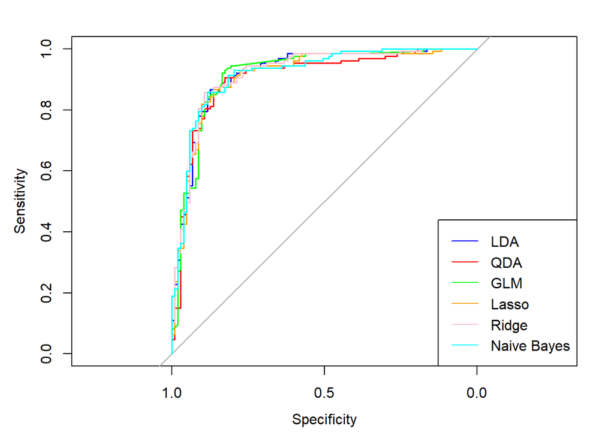

```r
roc.lda <- roc(test$HeartDisease, lda.res[,2])
roc.qda <- roc(test$HeartDisease, qda.pred$posterior[,2])
roc.glm <- roc(test$HeartDisease, prediction.glm.model.4)
roc.lasso <- roc(test$HeartDisease, lasso.y_pred)
roc.ridge <- roc(test$HeartDisease, ridge.y_pred)
roc.naivebayes <- roc(test$HeartDisease, naivebayes.prediction[,2])


plot(roc.lda, col = "blue", print.auc = FALSE, print.auc.y = 0, lwd=1.5)

lines(roc.qda, col = "red", print.auc = FALSE, print.auc.y = 0, lwd=1.5)
lines(roc.glm, col = "green", print.auc = FALSE, print.auc.y = 0, lwd=1.5)
lines(roc.lasso, col = "orange", print.auc = FALSE, print.auc.y = 0, lwd=1.5)
lines(roc.ridge, col = "pink", print.auc = FALSE, print.auc.y = 0, lwd=1.5)
lines(roc.naivebayes, col = "cyan", print.auc = FALSE, print.auc.y = 0,lwd=1.5)



legend("bottomright", legend = c("LDA", "QDA", "GLM","Lasso", "Ridge", "Naive Bayes"), col = c("blue", "red", "green", "orange", "pink", "cyan"), lty = 1)
```

## Conclusions

All models perform relatively good, with similar ROCs and each with their own strengths and weaknesses in their metrics. Considering Recall as most important, the best models are:

- GLM with Logistic Regression (Best threshold: 0.4): maximizes Recall
- LDA: Lowest FN-Rate
- GLM with Ridge

Considering all models, the very best predictors are:

- Sex[“M”]: males are more likely to suffer from CAD.
- ChestPainType[“ATA, “NAP”]: Atypical Angina is a known symptom preceding Myocardial Infarction. Non-Anginal Pain is non-ischemic related.
- ST_Slope[“Up”, “Flat”]: ST Segment Depression is a known anomaly of the electrophysiology of heart due to coronary blockage and therefore myocardial ischemia.
- Oldpeak: variations in ST Segment Depression induced by exercise relative to rest indicate myocardial ischemia.